# Exercise for Lecture 5 - more on differential expression with the limma package

```r
library(limma)
library(ggplot2)
library(reshape2)
library(ggforce)
library(dplyr)
library(plotROC)
library(matrixStats)
```

```r
nGenes <- 10000                   # number of "features"
nSamples <- 6                     # number of samples (split equal in 2 groups)
pDiff <- .1                       # percent of genes "differential
grp <- rep(0:1,each=nSamples/2)   # dummy variable for exp. group
trueFC <- 2                       # log-fold-change of truly DE

d0 <- 1
s0 <- 0.8
sd <- s0*sqrt(d0/rchisq(nGenes,df=d0))  # dist'n of s.d.
```

```r
y <- matrix(rnorm(nGenes*nSamples,sd=sd),
            nr=nGenes,nc=nSamples)
```

```r
indD <- 1:floor(pDiff*nGenes)
diff <- rep(0, nrow(y))
diff[indD] <- sample(c(-1,1),max(indD),replace=TRUE)*trueFC
table(diff)
```

```
## diff
##   -2    0    2
##  475 9000  525
```

```r
y[,grp==1] <- y[,grp==1] + diff
```

#### Question 1. First, do an exploratory analysis of the true and observed variances. For the observed variances, compute the *residual* variance for each row of `y` (i.e., pooled variance of the two simulated samples, not the row-wise variance; see the denominator of the classical two-sample *t*-statistic) and look at the distribution of them, of the true variances (from the simulated `sd`) and a scatter plot of true versus observed. Sometimes viewing variances on the log scale is preferred.

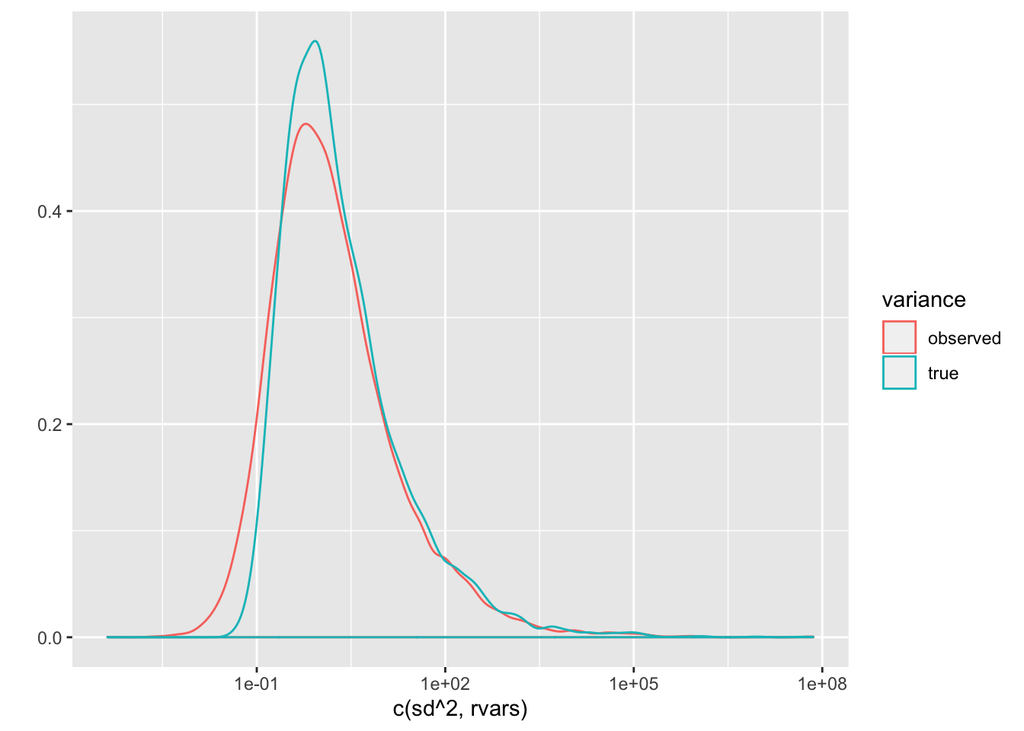

```r
rvars <- (rowVars(y[,grp==1]) + rowVars(y[,grp==0]))/2
variance <- rep(c("true","observed"), each=nGenes)

qplot(c(sd^2,rvars), geom="density", colour = variance) +
  scale_x_log10()
```

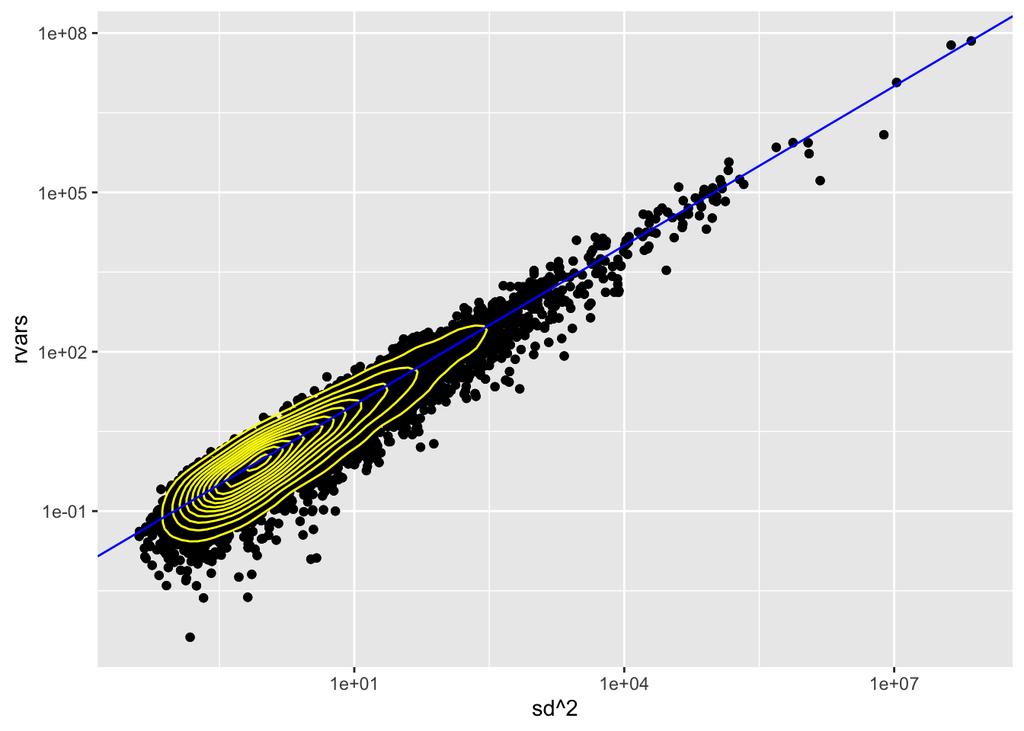

```r
# average below because both groups are same size
# otherwise, it would be weighted by n_1-1, n_2-1
qplot(sd^2, rvars) + geom_point() +
  scale_x_log10() + scale_y_log10() +
  geom_density_2d(col="yellow") +
  geom_abline(slope=1, intercept=0, col="blue")
```

#### Question 2. Produce an additional visualization to show that you understand the differential expression in the simulation.

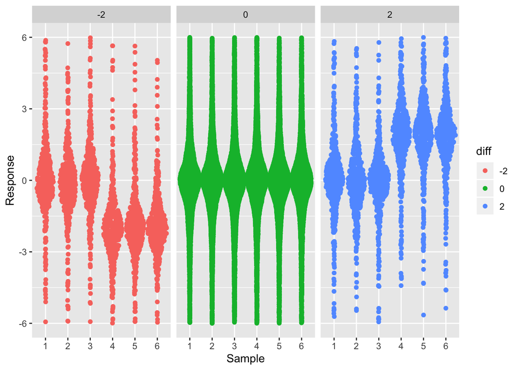

```r
m <- melt(y)
m$diff <- as.factor(diff)

ggplot(m, aes(x=factor(Var2), colour=diff, y=value)) +
  geom_sina() + ylim(-6,6) +
  xlab("Sample") + ylab("Response") + facet_grid(~diff)
```

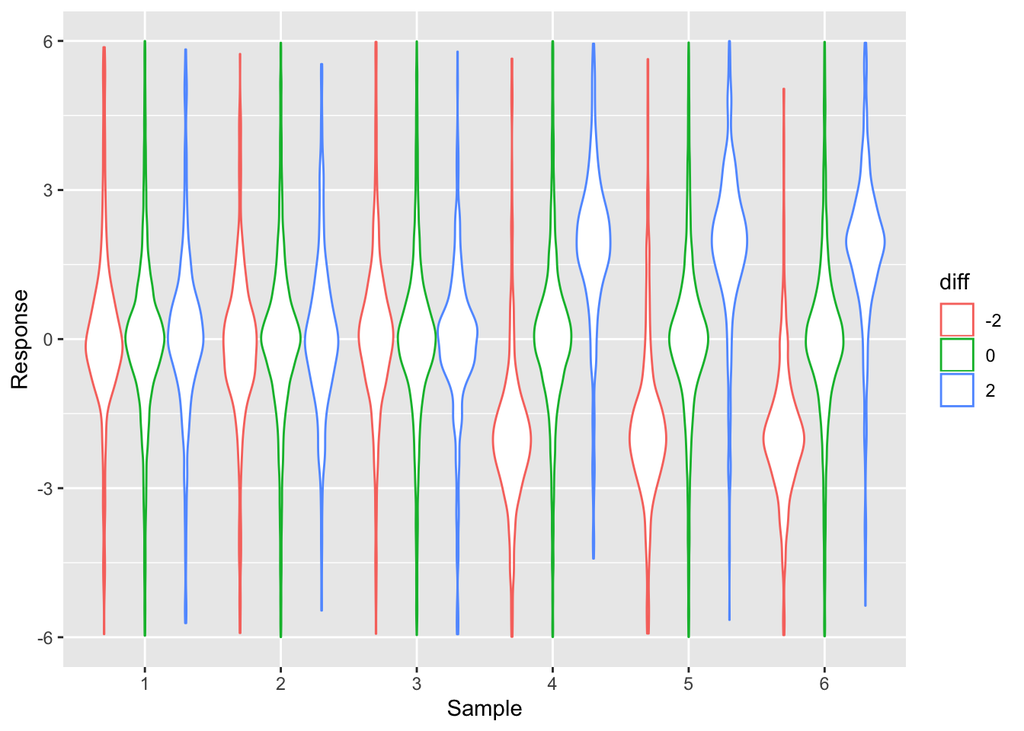

```r
ggplot(m, aes(x=factor(Var2), colour=diff, y=value)) +
  geom_violin() + ylim(-6,6) +
  xlab("Sample") + ylab("Response")
```

#### Question 3. In terms of the model that is fit for each feature, what is the interpretation of the two columns of this design matrix?

```r
(design <- model.matrix(~grp))
```

```
##   (Intercept) grp
## 1           1   0
## 2           1   0
## 3           1   0
## 4           1   1
## 5           1   1
## 6           1   1
## attr(,"assign")
## [1] 0 1
```

The first column represents the ‘intercept’ term and the second column represents the change in expression between the two groups.

```r
fit <- lmFit(y,design)
fit <- eBayes(fit)
```

#### Question 4. For each row of `y`, calculate also the classical 2-sample t-test. See ?t.test for more details about the built-in R function to do this calculation and convince yourself which arguments to use to match the classical t-test described in class. Add a visualization similar to the above plot for the classical t-statistic and the log-fold-change (mean difference). Which statistic best separates the truly differential from non-differential?

The easiest way to do this is from the summaries in the limma output - `t.test(.,var.equal=TRUE)` can do the same thing:

```r
# object contain
classical_t <- fit$coef[,2]/fit$sigma/fit$stdev.unscaled[,2]
```

```r
stats <- data.frame(moderated_t = fit$t[,2],
                    classical_t,
                    log_fold_change = fit$coef[,2],
                    diff = as.factor(diff))

m <- melt(stats)
```

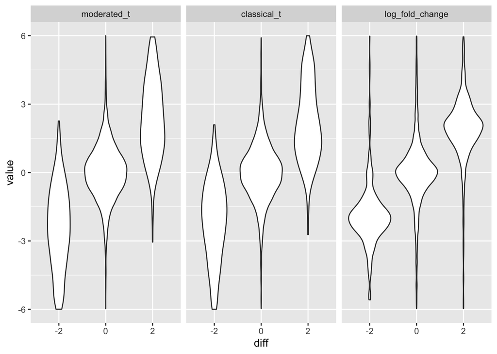

```r
m$index <- seq_len(length(classical_t))

ggplot(m, aes(x=diff, y=value)) + geom_violin() +
  facet_grid(~variable) + ylim(-6,6)
```

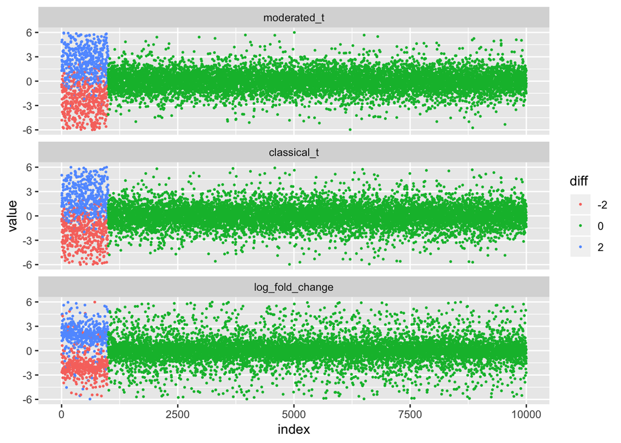

```r
ggplot(m, aes(x=index, y=value, colour=diff)) + geom_point(size=.4) +
  facet_wrap(~variable, ncol=1) + ylim(-6,6)
```

#### Question 5. Pick a reasonable metric to compare the methods, such as an ROC curve, false discovery plot, power versus achieved FDR. Using this metric/curve, formally compare the classical t-test, the moderated t-test and the log-fold-change or mean difference (fit$coef). Two packages that are useful for these kind of plots include: https://rocr.bioinf.mpi-sb.mpg.de/ or https://bioconductor.org/packages/release/bioc/html/iCOBRA.html.

There are many choices, but an ROC curve is one reasonable choice:

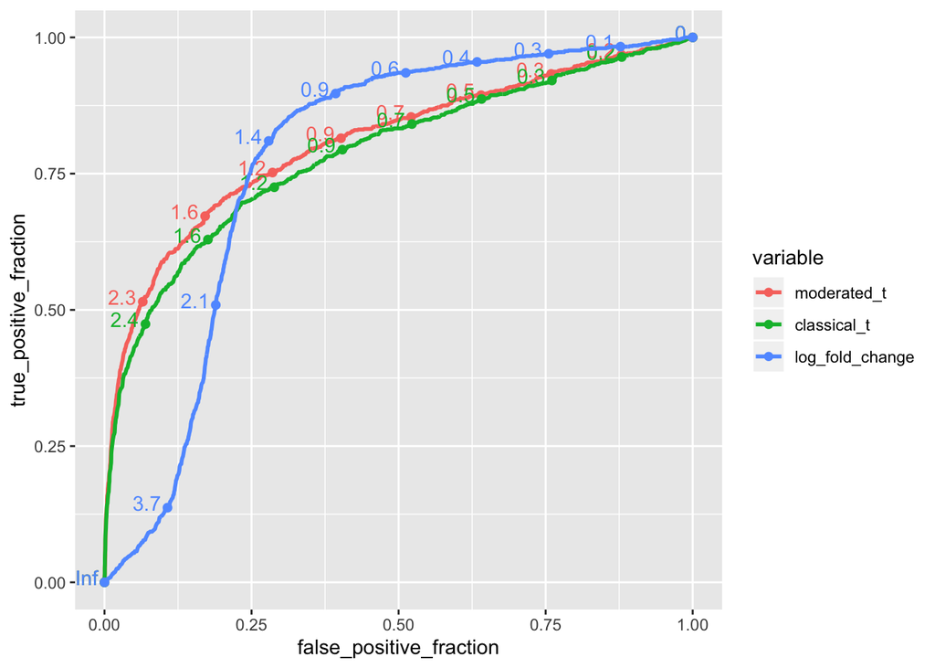

```r
ggplot(m, aes(m = abs(value), d = !(diff==0), colour=variable)) + geom_roc()
```

```r
library("limma")
library("affy")
library("preprocessCore")
unzip("affy_estrogen.zip")
ddir <- "affy_estrogen"
dir(ddir)
```

```
## [1] "high10-1.cel" "high10-2.cel" "high48-1.cel" "high48-2.cel"
## [5] "low10-1.cel"  "low10-2.cel"  "low48-1.cel"  "low48-2.cel"
## [9] "targets.txt"
```

```r
# preprocess affymetrix data
targets <- readTargets("targets.txt", path=ddir)
targets
```

```
##       filename estrogen time.h
## 1  low10-1.cel   absent     10
## 2  low10-2.cel   absent     10
## 3 high10-1.cel  present     10
## 4 high10-2.cel  present     10
## 5  low48-1.cel   absent     48
## 6  low48-2.cel   absent     48
## 7 high48-1.cel  present     48
## 8 high48-2.cel  present     48
```

```r
abatch <- ReadAffy(filenames=targets$filename,
                   celfile.path=ddir)
eset <- rma(abatch)  # bg correct, normalize, summarize
```

```
## Background correcting
## Normalizing
## Calculating Expression
```

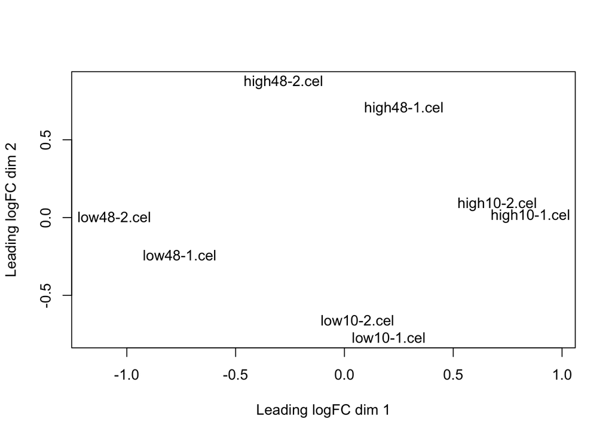

```r
plotMDS( exprs(eset) )  # MDS plot
```

```r
# do the limma modeling
f <- paste(targets$estrogen,targets$time.h,sep="")
f <- factor(f)

# create design matrix
design <- model.matrix(~0+f)
colnames(design) <- levels(f)
design
```

```
##   absent10 absent48 present10 present48
## 1        1        0         0         0
## 2        1        0         0         0
## 3        0        0         1         0
## 4        0        0         1         0
## 5        0        1         0         0
## 6        0        1         0         0
## 7        0        0         0         1
## 8        0        0         0         1
## attr(,"assign")
## [1] 1 1 1 1
## attr(,"contrasts")
## attr(,"contrasts")$f
## [1] "contr.treatment"
```

```r
fit <- lmFit(eset, design)
```

```r
cont.matrix <- makeContrasts(E10="present10-absent10",
                             E48="present48-absent48",
                             Time="absent48-absent10",levels=design)
cont.matrix
```

```
##            Contrasts
## Levels      E10 E48 Time
##   absent10   -1   0   -1
##   absent48    0  -1    1
##   present10   1   0    0
##   present48   0   1    0
```

```r
fit2  <- contrasts.fit(fit, cont.matrix)
fit2  <- eBayes(fit2)
#fit2
class(fit2)
```

```
## [1] "MArrayLM"
## attr(,"package")
## [1] "limma"
```

```r
names(fit2)
```

```
##  [1] "coefficients"     "rank"             "assign"
##  [4] "qr"               "df.residual"      "sigma"
##  [7] "cov.coefficients" "stdev.unscaled"   "Amean"
## [10] "method"           "design"           "contrasts"
## [13] "df.prior"         "s2.prior"         "var.prior"
## [16] "proportion"       "s2.post"          "t"
## [19] "df.total"         "p.value"          "lods"
## [22] "F"                "F.p.value"
```

```r
topTable(fit2,coef=1)
```

```
##              logFC   AveExpr        t      P.Value    adj.P.Val        B
## 39642_at  2.939428  7.876515 23.71715 4.741579e-09 3.128295e-05 9.966810
## 910_at    3.113733  9.660238 23.59225 4.955715e-09 3.128295e-05 9.942522
## 31798_at  2.800195 12.115778 16.38509 1.025747e-07 3.511070e-04 7.977290
## 41400_at  2.381040 10.041553 16.22463 1.112418e-07 3.511070e-04 7.916921
## 40117_at  2.555282  9.676557 15.68070 1.472942e-07 3.576234e-04 7.705093
## 1854_at   2.507616  8.532099 15.15848 1.945518e-07 3.576234e-04 7.490766
## 39755_at  1.679331 12.131839 15.06365 2.048314e-07 3.576234e-04 7.450643
## 1824_s_at 1.914637  9.238870 14.87915 2.266129e-07 3.576234e-04 7.371475
## 1126_s_at 1.782825  6.879918 13.83040 4.119252e-07 5.778395e-04 6.892307
## 1536_at   2.662258  5.937222 13.26247 5.795111e-07 7.316327e-04 6.610486
```

```r
topTable(fit2,coef=2)
```

```
##              logFC   AveExpr         t      P.Value    adj.P.Val         B
## 910_at    3.855061  9.660238  29.20918 8.266125e-10 1.043598e-05 11.606193
## 31798_at  3.597334 12.115778  21.04947 1.284430e-08 7.631722e-05  9.890557
## 1854_at   3.340896  8.532099  20.19564 1.813478e-08 7.631722e-05  9.641399
## 38116_at  3.758891  9.513109  16.85669 8.116230e-08 2.511100e-04  8.480197
## 38065_at  2.993641  9.097183  16.20914 1.121213e-07 2.511100e-04  8.214175
## 39755_at  1.765249 12.131839  15.83434 1.359405e-07 2.511100e-04  8.053134
## 1592_at   2.296484  8.311330  15.78841 1.392293e-07 2.511100e-04  8.033025
## 41400_at  2.243510 10.041553  15.28749 1.814762e-07 2.752126e-04  7.808295
## 33730_at -2.041390  8.573470 -15.14298 1.961911e-07 2.752126e-04  7.741556
## 1651_at   2.968283 10.504276  14.78097 2.392480e-07 3.020507e-04  7.570470
```

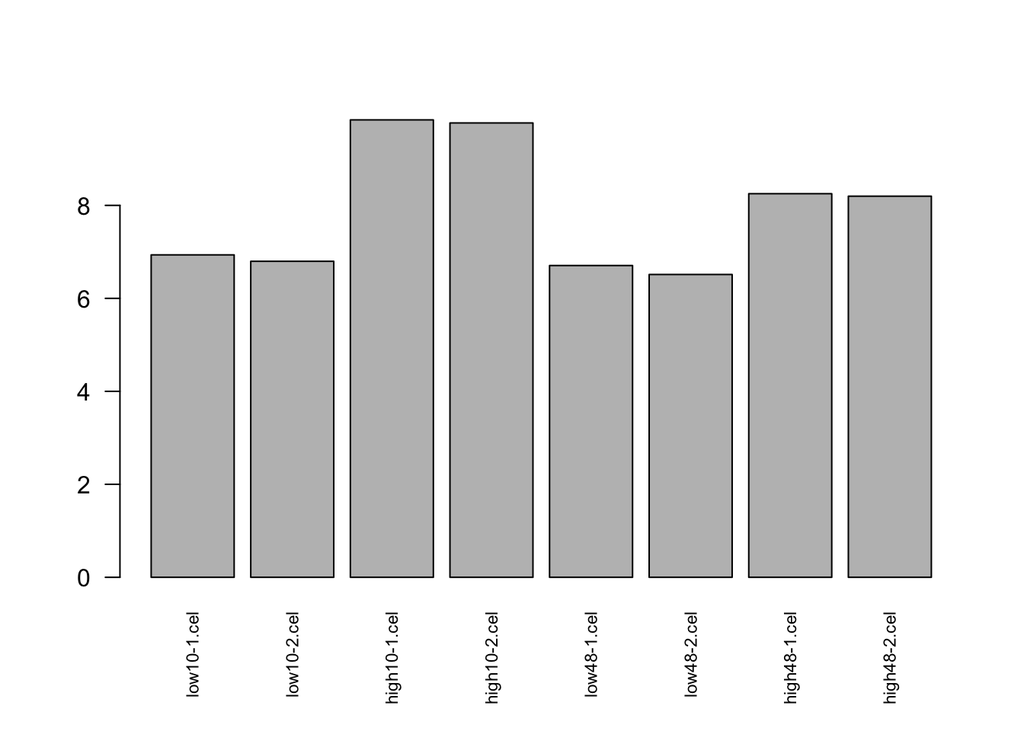

```r
barplot( exprs(eset)["39642_at",], las=2, cex.names=.7 )  # top gene
```

#### Question 6. From the matrix of summarized Affymetrix data that went into the limma pipeline in the first place (`exprs(eset)`), manually calculate the `logFC` and `AveExpr` for one of the top differentially expressed features.

As an example, I use ‘fit2’ and ‘coef=2’, which represents the contrast ‘present48-absent48’:

```r
tt <- topTable(fit2,coef=2)[1,]
tt
```

```
##           logFC  AveExpr        t      P.Value    adj.P.Val        B
## 910_at 3.855061 9.660238 29.20918 8.266125e-10 1.043598e-05 11.60619
```

```r
thise <- exprs(eset)[rownames(tt),]

mean(thise)  # AveExpr
```

```
## [1] 9.660238
```

```r
mean(thise[f=="present48"])-mean(thise[f=="absent48"])  # logFC
```

```
## [1] 3.855061
```